# Activité 5 - Analyse multivariée, imputation et valeurs aberrantes aberrantes

Andrés Silva

26/03/2020

**Objectifs de l’activité** :

- Imputer le valeurs manquantes
- Retirer les données aberrantes
- Effectuer une analyse discriminante linéaire

Tout d’abord, il faut charger les modules nécessaires pour le developpement de l’activité. Les modules utilisés sont :

- `tidyverse` sera utilisé pour manipuler et efectuer des opérations sur les tableux
- Le module `VIM` permet d’afficher la structure des données manquantes.
- L’imputation des données manquantes est fait avec le module `mice`.
- Le module `mvoutlier` sert à detecter les données aberrantes.
- L’analyse discriminante se fait avec le module `ade4`

La fonction `read_csv()` sert à lire le fichier contenant les données, lesquels sont stockées dans le tableau *data_dragon*. La fonction `set.seed()` sert à fixer les nombres aléatoires générés pendant le developpement de l’activité, afin d’éviter des changements dans les résultats des futures exécutions du code et de rendre le code reproductible.

```r
library(tidyverse)
library(VIM)
library(mice)
library(mvoutlier)
library(ade4)

set.seed(197273)
data_dragon <- read_csv("dragons.csv")
```

# 1 *Imputation de données manquantes*

La visualisation des données manquantes peut être faite avec la fonction `matrixplot()` du module `VIM`. En autre, la fonction `aggr()` (module `VIM`) permet visualiser la proportion de données manquantes par chacune des variables (segments) mesurées.

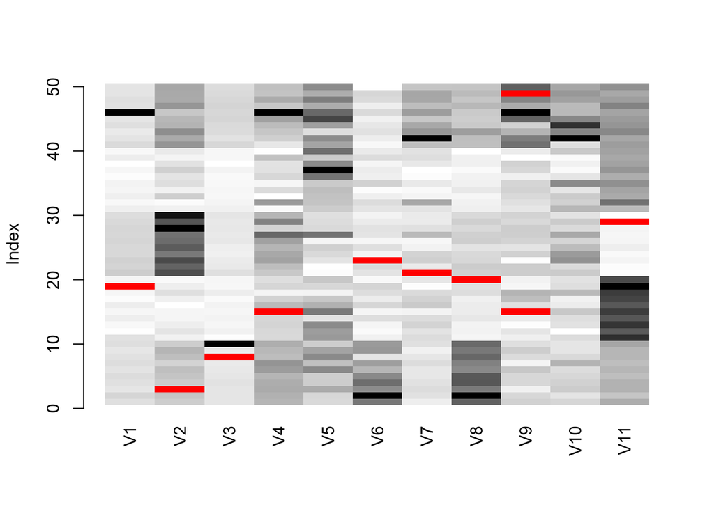

```r
matrixplot(data_dragon %>%
             select(-c(ID, Species)))
```

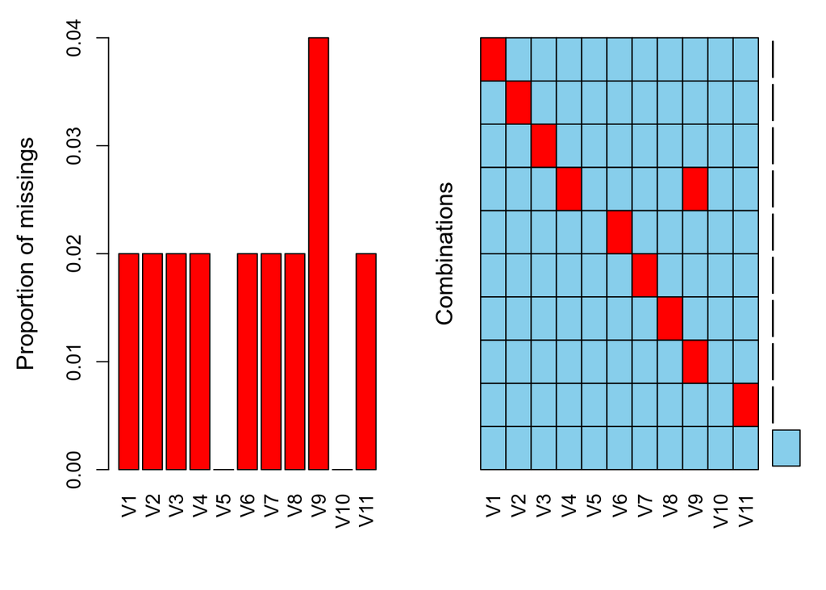

```r
#plot(aggr(data_dragon %>%
 #           select(-c(ID, Species))))
aggr(data_dragon %>%
        select(-c(ID, Species)))
```

En regardant les graphiques obtenus, il est évident que les seules variables qui n’ont pas de données manquantes sont *V5* et *V10*, tandis que la variable *V9* a la proportion la plus haute de données manquantes (2). La proportion des observations avec données manquantes par rappport au total d’observations est calculée avec les commandes du code ci-dessous.

```r
row_missing <- data_dragon %>%
  filter(apply(., 1, function(x) any(is.na(x))))

nrow(row_missing) / nrow(data_dragon)
```

```
## [1] 0.18
```

9 (18 %) des 50 observations ont au moins une donnée manquante. La fonction `mice()` fait l’imputation des données manquantes, cette fonction prend le tableau avec les données et utilise une méthode d’imputation choisie par l’utilisateur, dans ce cas la méthode **random forest** a été choisie. La fonction `complete()` remplace les données manquantes du tableau original par les données calculées par la fonction `mice()`. Finalement, il est fait un graphique avec la fonction `matrixplot()` afin de confirmer que toutes les données manquantes ont été imputées (pas de lignes rouges).

```r
dragons_mice <- mice(data_dragon %>%
                       select(-ID), method = "rf")
```

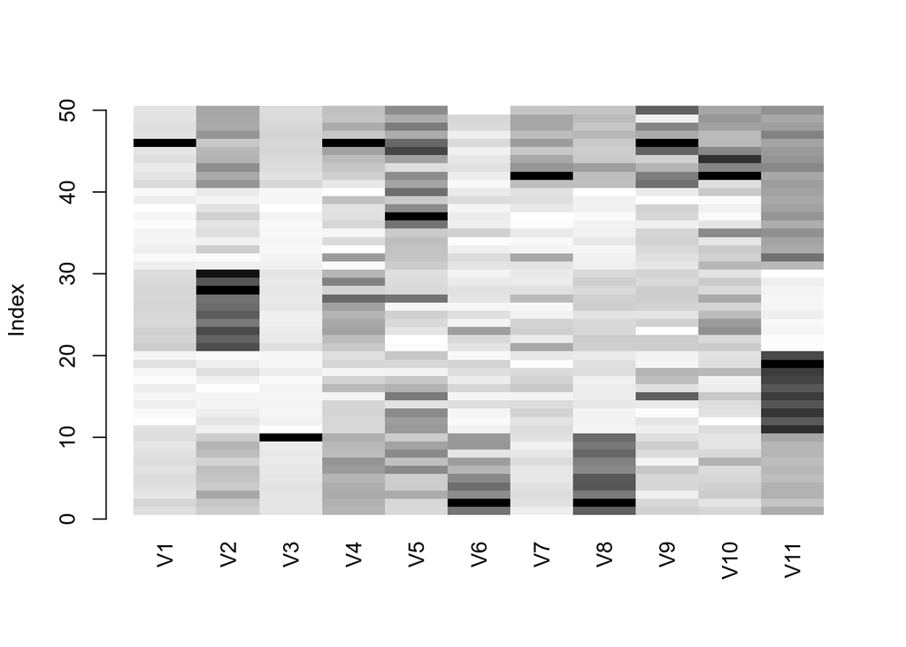

```r
dragons_imp <- complete(dragons_mice)
dragons_imp <- cbind("ID" = data_dragon$ID, dragons_imp)
matrixplot(dragons_imp %>%
             select(-ID, -Species))
```

Une fois que l’imputation des données manquantes est faite, il est possible de faire la detection des données aberrantes.

# 2 *Détection et élimination des données aberrantes*

Un premier stratégie pour détecter les données aberrantes est l’utilisation d’une méthode graphique. Dans ce cas, le boxplot a été utilisé.

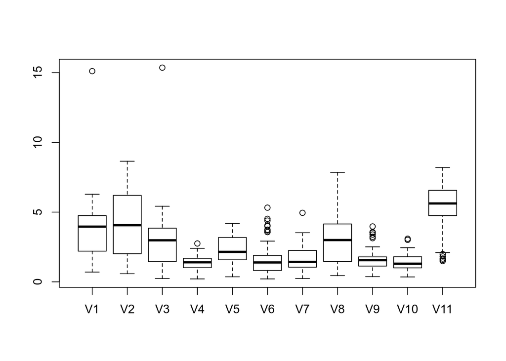

```r
boxplot(dragons_imp %>%
          select(-ID, -Species))
```

Les boxplot des différentes variables montrent que *V1* et *V3* ont toutes deux une valeur aberrante dont la valeur est proche de 15. *V7* semble avoir une valeur anormale d’environ 5. Dans le cas de *V4*, *V6*, *V9* et *V10*, il existe apparemment des valeurs aberrantes, mais ces cas sont moins évidents. Dans le but d’avoir une meilleure estimation des valeurs aberrantes, une méthode de détection par projection a été employée. En utilisant la fonction `sign2()` du module `mvoutlier`, il est possible de trouver les données anormales avec un seuil du $\chi^2_{\ df\ =\ 11;\ 0.975}$. La proportion des observations contenant des données aberrantes sur le nombre total d’observations est également calculée.

```r
niveau <- levels(factor(data_dragon$Species))
row_out <- c()

for (k in niveau) {
  out_temp <- sign2(dragons_imp %>%
                      filter(Species == k) %>%
                      select(-ID, -Species), qcrit = 0.975)$wfinal01
  row_out <- append(row_out, out_temp)
}
df_out <- dragons_imp[which(row_out == 0), ]
prop_aber <- sum(row_out == 0) / length(row_out)
```

```
## La proportion de valeurs aberrantes est :  0.16
```

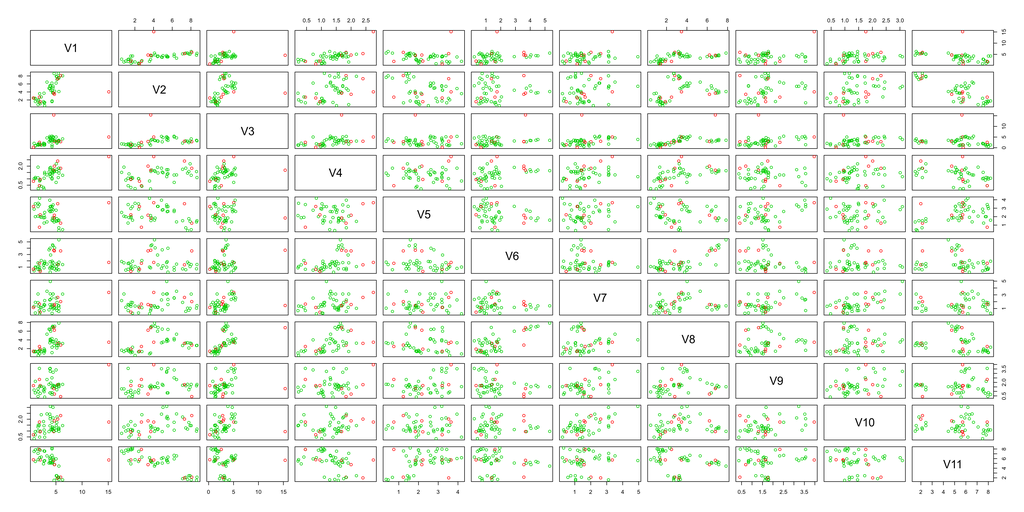

Tableau 1. Individus avec données aberrantes

|  | ID | Species | V1 | V2 | V3 | V4 | V5 | V6 | V7 | V8 | V9 | V10 | V11 |
| --- | --- | --- | --- | --- | --- | --- | --- | --- | --- | --- | --- | --- | --- |
| 7 | 7 | Dragon A | 4.7 | 3.41 | 2.92 | 2.00 | 2.17 | 3.57 | 1.58 | 6.22 | 0.70 | 1.86 | 4.74 |
| 10 | 10 | Dragon A | 4.59 | 3.70 | 15.36 | 1.68 | 1.84 | 3.68 | 1.44 | 6.80 | 1.31 | 0.95 | 5.65 |
| 18 | 18 | Dragon B | 1.85 | 2.70 | 2.54 | 0.46 | 0.75 | 1.61 | 1.65 | 2.49 | 2.33 | 1.76 | 7.90 |
| 23 | 23 | Dragon C | 5.9 | 8.09 | 2.82 | 1.83 | 1.23 | 3.57 | 2.01 | 2.81 | 0.42 | 2.31 | 2.14 |
| 27 | 27 | Dragon C | 5.34 | 7.31 | 3.04 | 2.40 | 3.53 | 1.37 | 2.62 | 3.20 | 1.75 | 2.01 | 1.99 |
| 34 | 34 | Dragon D | 1.99 | 1.57 | 1.42 | 0.95 | 2.22 | 0.33 | 0.46 | 1.88 | 1.65 | 0.93 | 5.72 |
| 38 | 38 | Dragon D | 0.7 | 2.49 | 0.23 | 0.81 | 3.2 | 0.67 | 1.15 | 1.40 | 1.64 | 0.68 | 5.76 |
| 46 | 46 | Dragon E | 15.11 | 4.02 | 5.04 | 2.75 | 3.65 | 1.75 | 3.35 | 3.47 | 3.97 | 1.76 | 5.71 |

```r
#runGitHub( "Activity5", "afsilvad", subdir = "/DragonPlots")
dragons_imp %>%
   filter(Species == "Dragon A")
```

```
##    ID  Species   V1   V2    V3   V4   V5   V6   V7   V8   V9  V10  V11
## 1   1 Dragon A 4.44 3.72  3.53 1.58 1.53 4.39 0.93 6.98 1.67 1.25 5.39
## 2   2 Dragon A 5.57 4.10  3.50 1.64 1.59 5.32 1.39 7.85 1.52 0.97 4.44
## 3   3 Dragon A 3.87 5.54  3.45 1.72 2.63 3.99 1.58 6.40 0.83 1.44 5.20
## 4   4 Dragon A 4.36 3.82  3.85 1.69 1.84 4.52 1.39 7.14 1.52 1.34 5.22
## 5   5 Dragon A 4.75 4.17  3.35 1.58 1.83 4.05 1.19 7.13 1.53 1.22 4.75
## 6   6 Dragon A 3.99 4.43  3.16 1.90 3.22 2.92 1.16 5.99 1.92 1.12 5.08
## 7   7 Dragon A 4.70 3.41  2.92 2.00 2.17 3.57 1.58 6.22 0.70 1.86 4.74
## 8   8 Dragon A 4.26 4.48  3.11 1.46 3.21 1.36 1.20 6.85 1.42 1.18 5.07
## 9   9 Dragon A 3.68 4.93  2.76 1.53 2.78 3.74 0.80 6.47 1.78 0.95 5.06
## 10 10 Dragon A 4.59 3.70 15.36 1.68 1.84 3.68 1.44 6.80 1.31 0.95 5.65
```

En observant toutes les variables mesurées des individus correspondant au *Dragon A* il est évident que la valeur aberrante de l’individu 10 correspond à la variable *V3* (15.36). Maintenant, il sont filtrées les données de l’espèce *Dragon E*.

```r
dragons_imp %>%
   filter(Species == "Dragon E")
```

```
##    ID  Species    V1   V2   V3   V4   V5   V6   V7   V8   V9  V10  V11
## 1  41 Dragon E  5.03 6.21 5.03 0.72 2.76 0.52 2.52 4.00 3.39 1.07 5.94
## 2  42 Dragon E  3.93 5.41 3.87 1.17 3.18 1.01 4.95 4.02 3.23 3.09 5.59
## 3  43 Dragon E  3.29 6.46 4.61 1.31 1.38 1.48 3.52 5.31 2.32 2.45 6.56
## 4  44 Dragon E  4.44 5.01 4.74 1.48 2.83 1.23 3.11 3.50 1.67 3.01 6.18
## 5  45 Dragon E  3.83 4.85 5.32 1.84 3.95 0.81 2.25 3.33 3.52 2.43 6.01
## 6  46 Dragon E 15.11 4.02 5.04 2.75 3.65 1.75 3.35 3.47 3.97 1.76 5.71
## 7  47 Dragon E  4.24 6.20 5.42 1.30 2.61 0.95 2.56 4.30 2.51 1.74 6.68
## 8  48 Dragon E  4.46 5.40 5.12 1.72 3.39 1.72 3.12 3.65 3.13 2.11 5.90
## 9  49 Dragon E  3.91 5.46 4.80 1.36 2.59 1.87 3.14 4.15 0.83 2.23 5.58
## 10 50 Dragon E  3.90 5.54 4.53 1.41 3.18 0.21 2.32 3.78 3.56 2.04 6.31
```

```r
dragons_imp$V1[46] <- NA; dragons_imp$V3[10] <- NA; dragons_imp$V7[42] <- NA
dragons_imp_mice <- mice(dragons_imp, method = "rf")
dragons_sans_out <- complete(dragons_imp_mice)
head(dragons_sans_out)
```

```
##   ID  Species   V1   V2   V3   V4   V5   V6   V7   V8   V9  V10  V11
## 1  1 Dragon A 4.44 3.72 3.53 1.58 1.53 4.39 0.93 6.98 1.67 1.25 5.39
## 2  2 Dragon A 5.57 4.10 3.50 1.64 1.59 5.32 1.39 7.85 1.52 0.97 4.44
## 3  3 Dragon A 3.87 5.54 3.45 1.72 2.63 3.99 1.58 6.40 0.83 1.44 5.20
## 4  4 Dragon A 4.36 3.82 3.85 1.69 1.84 4.52 1.39 7.14 1.52 1.34 5.22
## 5  5 Dragon A 4.75 4.17 3.35 1.58 1.83 4.05 1.19 7.13 1.53 1.22 4.75
## 6  6 Dragon A 3.99 4.43 3.16 1.90 3.22 2.92 1.16 5.99 1.92 1.12 5.08
```

Tableau 2. Résumé des valeurs remplaçant les valeurs aberrantes

| Espèce | Variable | Observation | Valeur Anormale | Valeur corrigée |
| --- | --- | --- | --- | --- |
| Dragon A | V3 | 10 | 15.36 | 3.49 |
| Dragon E | V7 | 42 | 4.95 | 1.05 |
| Dragon E | V1 | 46 | 15.11 | 3.93 |

# 3 *Analyse discriminante linéaire*

```r
dragon_pca <- dudi.pca(dragons_sans_out %>% select(-c(ID, Species)),
                     scannf = FALSE, # ne pas générer de graphique
                     scale = TRUE)

dragon_lda <- ade4::discrimin(dudi = dragon_pca,
                      fac = as.factor(dragons_sans_out$Species),
                      scannf = FALSE)
```